# ISLR 7

### 7.8.1

```r
library(ISLR2)
attach(Wage)
```

Coefficients for a 4th degree polynomial:

```r
fit <- lm(wage ~ poly(age, 4), data = Wage)
coef(summary(fit))
```

```
##                 Estimate Std. Error    t value     Pr(>|t|)
## (Intercept)    111.70361  0.7287409 153.283015 0.000000e+00
## poly(age, 4)1  447.06785 39.9147851  11.200558 1.484604e-28
## poly(age, 4)2 -478.31581 39.9147851 -11.983424 2.355831e-32
## poly(age, 4)3  125.52169 39.9147851   3.144742 1.678622e-03
## poly(age, 4)4  -77.91118 39.9147851  -1.951938 5.103865e-02
```

`poly(age, 4)` is a matrix whose columns are linear combinations of `age, age^2, ...`

Found this for the mathematical definition of poly: > A quick answer is that poly of a vector is x essentially equivalent to the QR decomposition of the matrix whose columns are powers of x

Some more details [here](https://www.sydney.edu.au/science/chemistry/~mjtj/CHEM3117/Resources/poly_etc.pdf)

```r
m <- poly(age, 4)
dim(m)
```

```
## [1] 3000    4
```

```r
dim(Wage)
```

```
## [1] 3000   11
```

```r
fit2 <- lm(wage ~ poly(age, 4, raw=TRUE), data = Wage)
coef(summary(fit2))
```

```
##                                Estimate   Std. Error   t value     Pr(>|t|)
## (Intercept)               -1.841542e+02 6.004038e+01 -3.067172 0.0021802539
## poly(age, 4, raw = TRUE)1  2.124552e+01 5.886748e+00  3.609042 0.0003123618
## poly(age, 4, raw = TRUE)2 -5.638593e-01 2.061083e-01 -2.735743 0.0062606446
## poly(age, 4, raw = TRUE)3  6.810688e-03 3.065931e-03  2.221409 0.0263977518
## poly(age, 4, raw = TRUE)4 -3.203830e-05 1.641359e-05 -1.951938 0.0510386498
```

Similarly

```r
fit2a <- lm(wage ~ age + I(age^2) + I(age^3) + I(age^4), data = Wage)
coef(fit2a)
```

```
##   (Intercept)           age      I(age^2)      I(age^3)      I(age^4)
## -1.841542e+02  2.124552e+01 -5.638593e-01  6.810688e-03 -3.203830e-05
```

Slightly different way:

```r
fit2b <- lm(wage ~ cbind(age, age^2, age^3, age^4), data = Wage)
coef(fit2b)
```

```
##                        (Intercept) cbind(age, age^2, age^3, age^4)age
##                      -1.841542e+02                       2.124552e+01
##    cbind(age, age^2, age^3, age^4)    cbind(age, age^2, age^3, age^4)
##                      -5.638593e-01                       6.810688e-03
##    cbind(age, age^2, age^3, age^4)
##                      -3.203830e-05
```

Prediction:

```r
agelims <- range(age)
age.grid <- seq(from = agelims[1], to = agelims[2])
preds <- predict(fit, newdata = list(age = age.grid), se = TRUE)
se.bands <- cbind(preds$fit + 2 * preds$se.fit, preds$fit - 2 * preds$se.fit)
```

?

```r
par(mfrow = c(1, 2), mar = c(4.5, 4.5, 1, 1), oma = c(0, 0, 4, 0))
plot(age, wage, xlim = agelims, cex = .5, col = "darkgrey") > title("Degree-4 Polynomial", outer = T)
```

```
## logical(0)
```

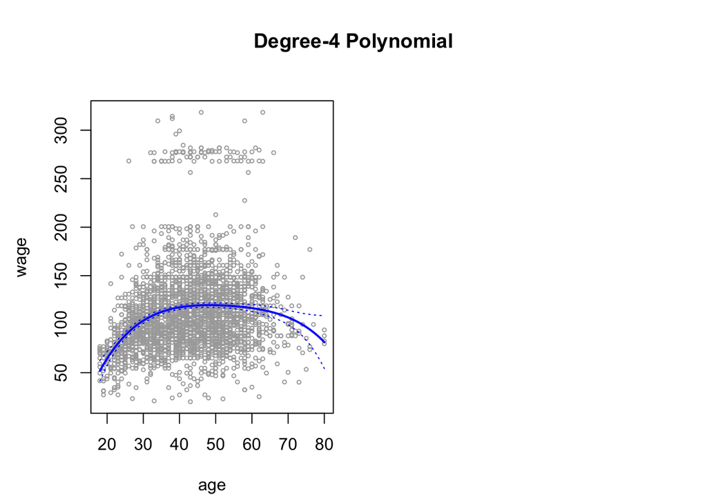

```r
lines(age.grid, preds$fit, lwd = 2, col = "blue")
matlines(age.grid, se.bands, lwd = 1, col = "blue", lty = 3)
```

?

```r
preds2 <- predict(fit2, newdata = list(age = age.grid), se = TRUE)
max(abs(preds$fit - preds2$fit))
```

```
## [1] 4.575895e-12
```

ANOVA

```r
fit.1 <- lm(wage ~ age, data = Wage)
fit.2 <- lm(wage ~ poly(age, 2), data = Wage)
fit.3 <- lm(wage ~ poly(age, 3), data = Wage)
fit.4 <- lm(wage ~ poly(age, 4), data = Wage)
fit.5 <- lm(wage ~ poly(age, 5), data = Wage)
anova(fit.1, fit.2, fit.3, fit.4, fit.5)
```

|  | Res.Df | RSS | Df | Sum of Sq | F | Pr(>F) |
| --- | --- | --- | --- | --- | --- | --- |
| 1 | 2998 | 5022216 | NA | NA | NA | NA |
| 2 | 2997 | 4793430 | 1 | 228786.010 | 143.5931074 | 2.367734e-32 |
| 3 | 2996 | 4777674 | 1 | 15755.694 | 9.8887559 | 1.679213e-03 |
| 4 | 2995 | 4771604 | 1 | 6070.152 | 3.8098134 | 5.104623e-02 |
| 5 | 2994 | 4770322 | 1 | 1282.563 | 0.8049758 | 3.696820e-01 |

```r
coef(summary(fit.5))
```

```
##                 Estimate Std. Error     t value     Pr(>|t|)
## (Intercept)    111.70361  0.7287647 153.2780243 0.000000e+00
## poly(age, 5)1  447.06785 39.9160847  11.2001930 1.491111e-28
## poly(age, 5)2 -478.31581 39.9160847 -11.9830341 2.367734e-32
## poly(age, 5)3  125.52169 39.9160847   3.1446392 1.679213e-03
## poly(age, 5)4  -77.91118 39.9160847  -1.9518743 5.104623e-02
## poly(age, 5)5  -35.81289 39.9160847  -0.8972045 3.696820e-01
```

Adding `education`:

```r
fit.1 <- lm(wage ~ education + age, data = Wage)
fit.2 <- lm(wage ~ education + poly(age, 2), data = Wage)
fit.3 <- lm(wage ~ education + poly(age, 3), data = Wage)
anova(fit.1, fit.2, fit.3)
```

|  | Res.Df | RSS | Df | Sum of Sq | F | Pr(>F) |
| --- | --- | --- | --- | --- | --- | --- |
| 1 | 2994 | 3867992 | NA | NA | NA | NA |
| 2 | 2993 | 3725395 | 1 | 142597.10 | 114.696898 | 2.728971e-26 |
| 3 | 2992 | 3719809 | 1 | 5586.66 | 4.493588 | 3.410431e-02 |

Using `glm`:

```r
fit <- glm(I(wage > 250) ~ poly(age, 4), data = Wage, family = binomial)
```

?

```r
preds <- predict(fit, newdata = list(age = age.grid), se = T)
summary(preds)
```

```
##                Length Class  Mode
## fit            63     -none- numeric
## se.fit         63     -none- numeric
## residual.scale  1     -none- numeric
```

?

```r
pfit <- exp(preds$fit) / (1 + exp(preds$fit))
se.bands.logit <- cbind(preds$fit + 2 * preds$se.fit,
preds$fit - 2 * preds$se.fit)
se.bands <- exp(se.bands.logit) / (1 + exp(se.bands.logit))
# same as the below?
preds <- predict(fit, newdata = list(age = age.grid), type = "response", se = T)
```

?

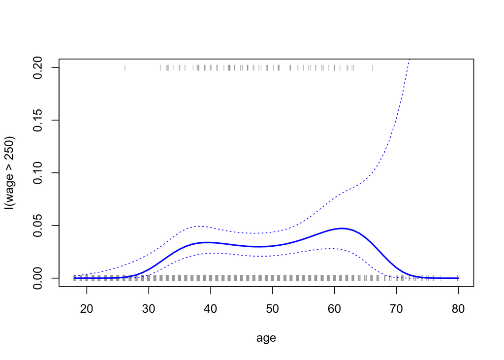

```r
plot(age, I(wage > 250), xlim = agelims, type = "n", ylim = c(0, .2))
points(jitter(age), I((wage > 250) / 5), cex = .5, pch = "|", col = "darkgrey")
lines(age.grid, pfit, lwd = 2, col = "blue")
matlines(age.grid, se.bands, lwd = 1, col = "blue", lty = 3)
```

```r
table(cut(age, 4))
```

```
##
## (17.9,33.5]   (33.5,49]   (49,64.5] (64.5,80.1]
##         750        1399         779          72
```

```r
fit <- lm(wage ~ cut(age, 4), data = Wage)
coef(summary(fit))
```

```
##                         Estimate Std. Error   t value     Pr(>|t|)
## (Intercept)            94.158392   1.476069 63.789970 0.000000e+00
## cut(age, 4)(33.5,49]   24.053491   1.829431 13.148074 1.982315e-38
## cut(age, 4)(49,64.5]   23.664559   2.067958 11.443444 1.040750e-29
## cut(age, 4)(64.5,80.1]  7.640592   4.987424  1.531972 1.256350e-01
```

?

### 7.8.2

TIL: `bs` stands for `B-splines`. the set of all cubic splines going through those notes is a vector space, and the basis of that vector space are b-splines. so by expressing splines using those basis functions we are uniquely expressing them.

```r
library(ISLR2)
attach(Wage)
```

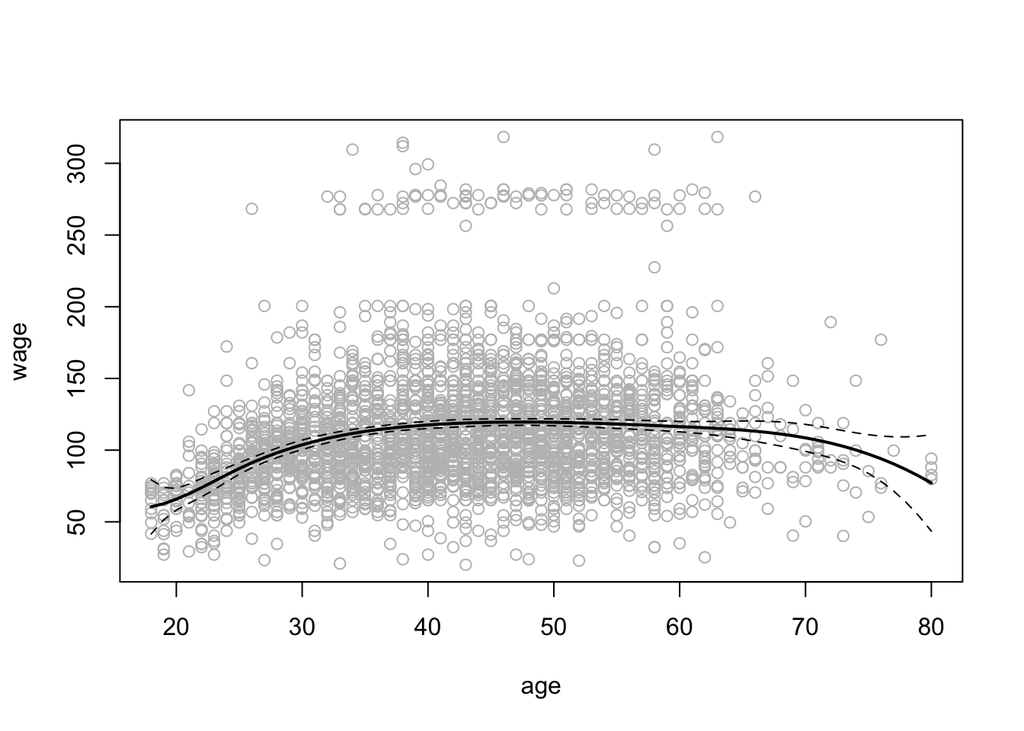

```r
library(splines)
fit <- lm(wage ~ bs(age, knots = c(25, 40, 60)), data = Wage)
pred <- predict(fit, newdata = list(age = age.grid), se = T)
plot(age, wage, col = "gray")
lines(age.grid, pred$fit, lwd = 2)
lines(age.grid, pred$fit + 2 * pred$se, lty = "dashed")
lines(age.grid, pred$fit - 2 * pred$se, lty = "dashed")
```

knots at uniformed quantiles:

```r
dim(bs(age, knots = c(25, 40, 60)))
```

```
## [1] 3000    6
```

```r
dim(bs(age, df = 6)) # 3 internal knots - k = df - degree
```

```
## [1] 3000    6
```

```r
attr(bs(age, df = 6), "knots")
```

```
## [1] 33.75 42.00 51.00
```

use `ns` for natural splines (normal cubic splines are cubic outside of the knots on both ends, natural splines are constrained to be linear at the boundaries - meaning the cubic and quadratic coefs are zero):

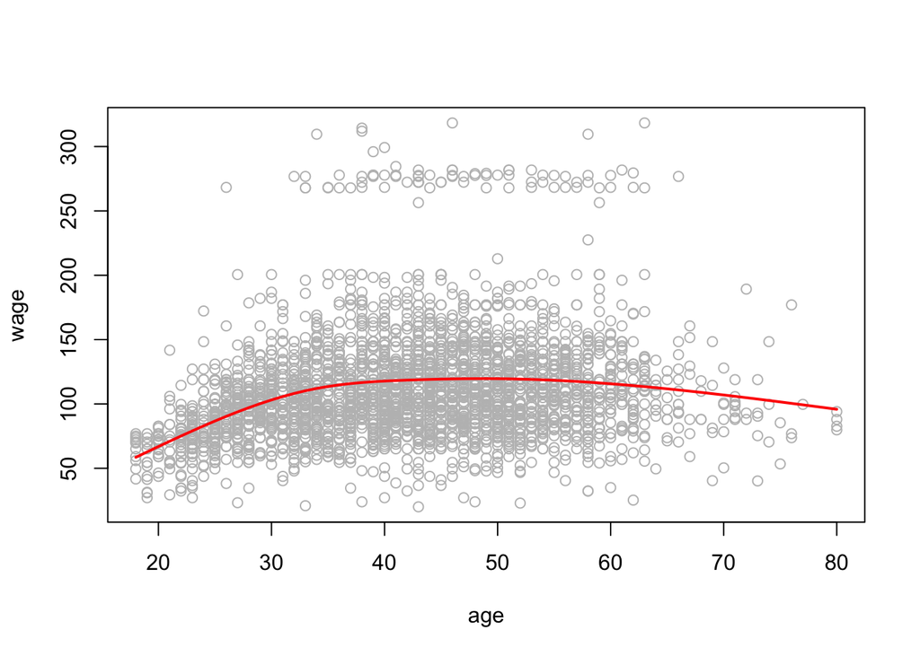

```r
fit2 <- lm(wage ~ ns(age, df = 4), data = Wage)
pred2 <- predict(fit2, newdata = list(age = age.grid), se = T)
plot(age, wage, col = "gray")
lines(age.grid, pred2$fit, col = "red", lwd = 2)
```

using smooth splines (those are the ones with a penality term):

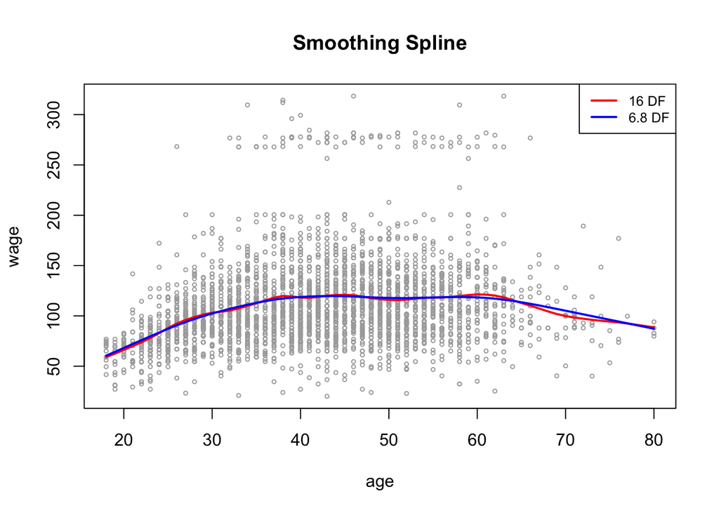

```r
plot(age, wage, xlim = agelims, cex = .5, col = "darkgrey")
title("Smoothing Spline")
fit <- smooth.spline(age, wage, df = 16)
fit2 <- smooth.spline(age, wage, cv = TRUE)
lines(fit, col = "red", lwd = 2)
lines(fit2, col = "blue", lwd = 2)
legend("topright", legend = c("16 DF", "6.8 DF"),
col = c("red", "blue"), lty = 1, lwd = 2, cex = .8)
```

```r
fit2$df
```

```
## [1] 6.794596
```

local regression - using a span of 20% and one of 50% (for the observations in the vicinity of $x_0$)

```r
plot(age, wage, xlim = agelims, cex = .5, col = "darkgrey") > title("Local Regression")
```

```
## logical(0)
```

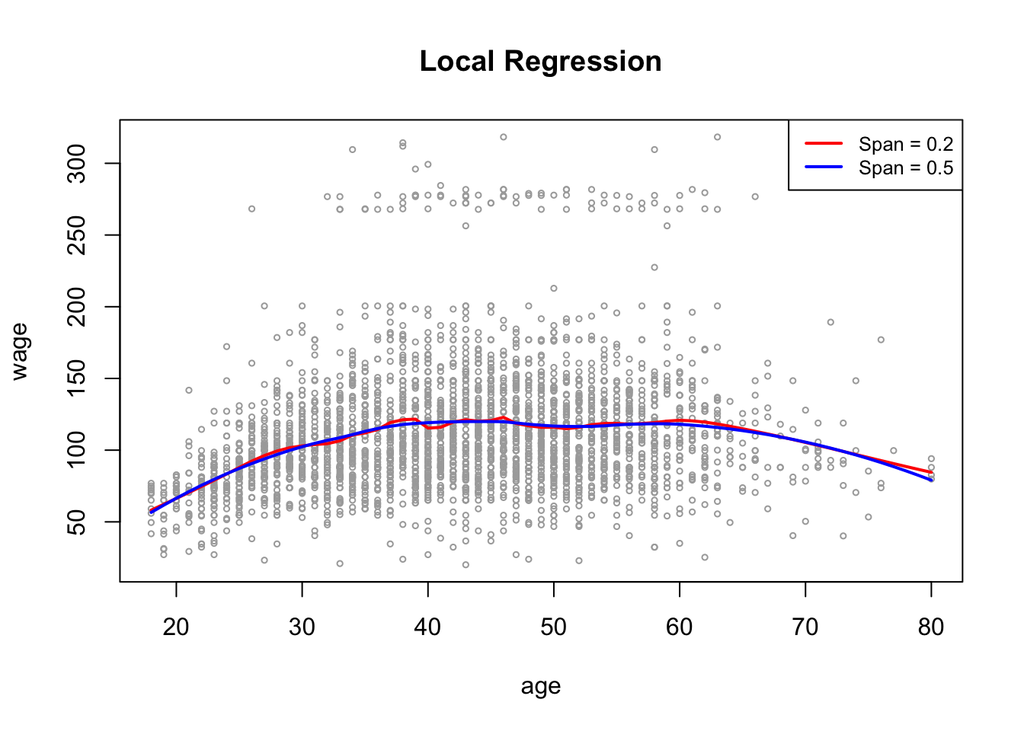

```r
fit <- loess(wage ~ age, span = .2, data = Wage)
fit2 <- loess(wage ~ age, span = .5, data = Wage)
lines(age.grid, predict(fit, data.frame(age = age.grid)), col = "red", lwd = 2)
lines(age.grid, predict(fit2, data.frame(age = age.grid)), col = "blue", lwd = 2)
legend("topright", legend = c("Span = 0.2", "Span = 0.5"), col = c("red", "blue"), lty = 1, lwd = 2, cex = .8)
```

### 7.9.3

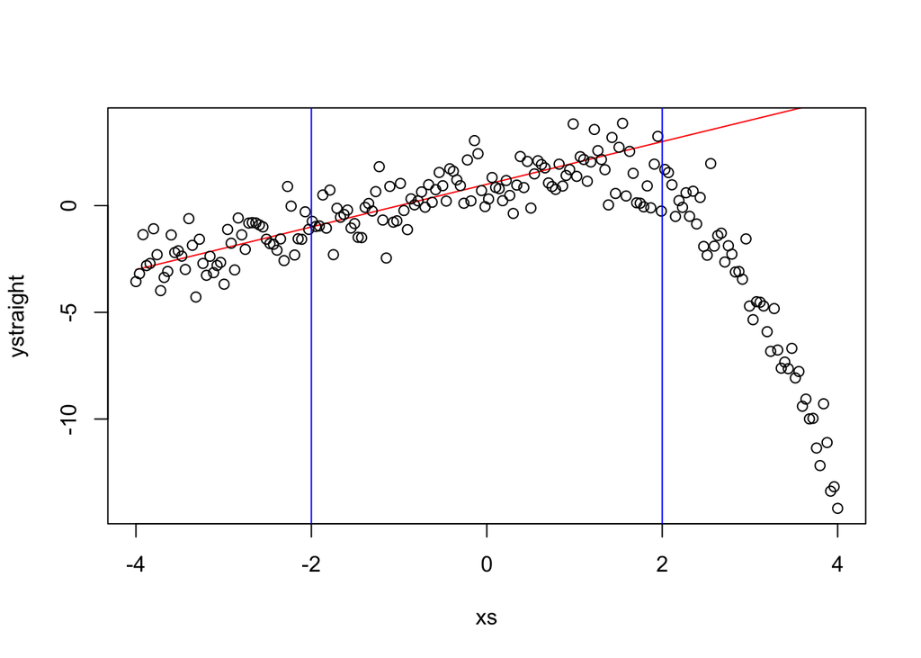

```r
b0 <- 1
b1 <- 1
b2 <- -2
set.seed(123)
xs <- seq(-4,4,length=200)
indic <- ifelse(xs>=1,1,0)
y <- b0+b1*xs+b2*indic*((xs-1)^2)+rnorm(length(xs))
ystraight <- b0+b1*xs

plot(xs,ystraight, col="red",type="l",xlim=c(min(xs),max(xs)),ylim=c(min(y),max(y)))
points(xs,y)
abline(v=-2, col="blue")
abline(v=2, col="blue")
```

### 7.9.6

1. polynomial regression of `wage` vs `age`

```r
set.seed(45)
numRows <- dim(Wage)[1]
train <- sample(numRows, numRows*0.7)
max_d <- 10

mses <- rep(0, max_d)
fits <- list()
for (d in seq(1,max_d)) {
  lm.fit <- lm(wage ~ poly(age, d), data = Wage, subset=train)
  mses[d] <- mean((wage - predict(lm.fit, Wage))[-train]^2)
  fits[[d]] <- lm.fit
}



fits <- lapply(1:max_d, function(i) lm(wage ~ poly(age, i), data = Wage, subset=train))

bestDegree <- which.min(mses)
bestDegree
```

```
## [1] 9
```

```r
do.call("anova", fits)
```

|  | Res.Df | RSS | Df | Sum of Sq | F | Pr(>F) |
| --- | --- | --- | --- | --- | --- | --- |
| 1 | 2098 | 3712844 | NA | NA | NA | NA |
| 2 | 2097 | 3522839 | 1 | 190005.37343 | 113.39864317 | 8.002364e-26 |
| 3 | 2096 | 3512802 | 1 | 10036.80253 | 5.99014527 | 1.446784e-02 |
| 4 | 2095 | 3509911 | 1 | 2890.98910 | 1.72539458 | 1.891444e-01 |
| 5 | 2094 | 3507271 | 1 | 2639.52334 | 1.57531527 | 2.095772e-01 |
| 6 | 2093 | 3504030 | 1 | 3241.56670 | 1.93462563 | 1.644014e-01 |
| 7 | 2092 | 3501861 | 1 | 2168.75773 | 1.29435383 | 2.553776e-01 |
| 8 | 2091 | 3501808 | 1 | 52.59191 | 0.03138780 | 8.593952e-01 |
| 9 | 2090 | 3500306 | 1 | 1502.74265 | 0.89686399 | 3.437335e-01 |
| 10 | 2089 | 3500229 | 1 | 76.63401 | 0.04573657 | 8.306763e-01 |

plotting the one with the best degree:

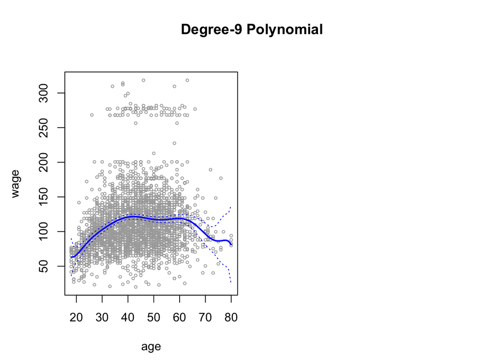

```r
fit <- fits[bestDegree][[1]]
agelims <- range(age)
age.grid <- seq(from = agelims[1], to = agelims[2])
preds <- predict(fit, newdata = list(age = age.grid), se = TRUE)
se.bands <- cbind(preds$fit + 2 * preds$se.fit, preds$fit - 2 * preds$se.fit)
par(mfrow = c(1, 2), mar = c(4.5, 4.5, 1, 1), oma = c(0, 0, 4, 0))
plot(age, wage, xlim = agelims, cex = .5, col = "darkgrey")
title("Degree-9 Polynomial", outer = T)
lines(age.grid, preds$fit, lwd = 2, col = "blue")
matlines(age.grid, se.bands, lwd = 1, col = "blue", lty = 3)
```

2. using step functions

```r
table(cut(age, 4))
```

```
##
## (17.9,33.5]   (33.5,49]   (49,64.5] (64.5,80.1]
##         750        1399         779          72
```

```r
fits <- lapply(2:max_d, function(d) lm(wage ~ cut(age, d), data = Wage, subset=train))
mses <- rep(0, max_d-2)
for (d in seq(1,max_d-1)) {
  mses[d] <- mean((wage - predict(fits[[d]], Wage))[-train]^2)
}

bestDegree <- which.min(mses)
bestDegree
```

```
## [1] 7
```

[figure not shown]

```r
fit <- fits[bestDegree][[1]]
agelims <- range(age)
age.grid <- seq(from = agelims[1], to = agelims[2])
preds <- predict(fit, newdata = list(age = age.grid), se = TRUE)
se.bands <- cbind(preds$fit + 2 * preds$se.fit, preds$fit - 2 * preds$se.fit)
par(mfrow = c(1, 2), mar = c(4.5, 4.5, 1, 1), oma = c(0, 0, 4, 0))
plot(age, wage, xlim = agelims, cex = .5, col = "darkgrey")
title("Degree-9 Polynomial", outer = T)
lines(age.grid, preds$fit, lwd = 2, col = "blue")
matlines(age.grid, se.bands, lwd = 1, col = "blue", lty = 3)
```